# sklearn.svm.SVC

**class*sklearn.svm.SVC(*, *C=1.0*, *kernel='rbf'*, *degree=3*, *gamma='scale'*, *coef0=0.0*, *shrinking=True*, *probability=False*, *tol=0.001*, *cache_size=200*, *class_weight=None*, *verbose=False*, *max_iter=-1*, *decision_function_shape='ovr'*, *break_ties=False*, *random_state=None*)[[source]](https://github.com/scikit-learn/scikit-learn/blob/f3f51f9b6/sklearn/svm/_classes.py#L525)**

C-Support Vector Classification.

The implementation is based on libsvm. The fit time scales at least quadratically with the number of samples and may be impractical beyond tens of thousands of samples. For large datasets consider using `LinearSVC` or `SGDClassifier` instead, possibly after a `Nystroem` transformer.

The multiclass support is handled according to a one-vs-one scheme.

For details on the precise mathematical formulation of the provided kernel functions and how `gamma`, `coef0` and `degree` affect each other, see the corresponding section in the narrative documentation: Kernel functions.

Read more in the User Guide.

**Parameters:**

**C**float, default=1.0**

Regularization parameter. The strength of the regularization is inversely proportional to C. Must be strictly positive. The penalty is a squared l2 penalty.

**kernel**{‘linear’, ‘poly’, ‘rbf’, ‘sigmoid’, ‘precomputed’} or callable, default=’rbf’**

Specifies the kernel type to be used in the algorithm. If none is given, ‘rbf’ will be used. If a callable is given it is used to pre-compute the kernel matrix from data matrices; that matrix should be an array of shape `(n_samples, n_samples)`.

**degree**int, default=3**

Degree of the polynomial kernel function (‘poly’). Ignored by all other kernels.

**gamma**{‘scale’, ‘auto’} or float, default=’scale’**

Kernel coefficient for ‘rbf’, ‘poly’ and ‘sigmoid’.

- if `gamma='scale'` (default) is passed then it uses 1 / (n_features * X.var()) as value of gamma,
- if ‘auto’, uses 1 / n_features.

Changed in version 0.22: The default value of `gamma` changed from ‘auto’ to ‘scale’.

**coef0**float, default=0.0**

Independent term in kernel function. It is only significant in ‘poly’ and ‘sigmoid’.

**shrinking**bool, default=True**

Whether to use the shrinking heuristic. See the User Guide.

**probability**bool, default=False**

Whether to enable probability estimates. This must be enabled prior to calling `fit`, will slow down that method as it internally uses 5-fold cross-validation, and `predict_proba` may be inconsistent with `predict`. Read more in the User Guide.

**tol**float, default=1e-3**

Tolerance for stopping criterion.

**cache_size**float, default=200**

Specify the size of the kernel cache (in MB).

**class_weight**dict or ‘balanced’, default=None**

Set the parameter C of class i to class_weight[i]*C for SVC. If not given, all classes are supposed to have weight one. The “balanced” mode uses the values of y to automatically adjust weights inversely proportional to class frequencies in the input data as `n_samples / (n_classes * np.bincount(y))`.

**verbose**bool, default=False**

Enable verbose output. Note that this setting takes advantage of a per-process runtime setting in libsvm that, if enabled, may not work properly in a multithreaded context.

**max_iter**int, default=-1**

Hard limit on iterations within solver, or -1 for no limit.

**decision_function_shape**{‘ovo’, ‘ovr’}, default=’ovr’**

Whether to return a one-vs-rest (‘ovr’) decision function of shape (n_samples, n_classes) as all other classifiers, or the original one-vs-one (‘ovo’) decision function of libsvm which has shape (n_samples, n_classes * (n_classes - 1) / 2). However, note that internally, one-vs-one (‘ovo’) is always used as a multi-class strategy to train models; an ovr matrix is only constructed from the ovo matrix. The parameter is ignored for binary classification.

Changed in version 0.19: decision_function_shape is ‘ovr’ by default.

New in version 0.17: *decision_function_shape=’ovr’* is recommended.

Changed in version 0.17: Deprecated *decision_function_shape=’ovo’ and None*.

**break_ties**bool, default=False**

If true, `decision_function_shape='ovr'`, and number of classes > 2, predict will break ties according to the confidence values of decision_function; otherwise the first class among the tied classes is returned. Please note that breaking ties comes at a relatively high computational cost compared to a simple predict.

New in version 0.22.

**random_state**int, RandomState instance or None, default=None**

Controls the pseudo random number generation for shuffling the data for probability estimates. Ignored when `probability` is False. Pass an int for reproducible output across multiple function calls. See [Glossary](https://scikit-learn.org/1.1/glossary.html#term-random_state).

**Attributes:**

**class_weight_**ndarray of shape (n_classes,)**

Multipliers of parameter C for each class. Computed based on the `class_weight` parameter.

**classes_**ndarray of shape (n_classes,)**

The classes labels.

**`coef_`ndarray of shape (n_classes * (n_classes - 1) / 2, n_features)**

Weights assigned to the features when `kernel="linear"`.

**dual_coef_**ndarray of shape (n_classes -1, n_SV)**

Dual coefficients of the support vector in the decision function (see Mathematical formulation), multiplied by their targets. For multiclass, coefficient for all 1-vs-1 classifiers. The layout of the coefficients in the multiclass case is somewhat non-trivial. See the multi-class section of the User Guide for details.

**fit_status_**int**

0 if correctly fitted, 1 otherwise (will raise warning)

**intercept_**ndarray of shape (n_classes * (n_classes - 1) / 2,)**

Constants in decision function.

**n_features_in_**int**

Number of features seen during fit.

New in version 0.24.

**feature_names_in_**ndarray of shape (`n_features_in_`,)**

Names of features seen during fit. Defined only when `X` has feature names that are all strings.

New in version 1.0.

**n_iter_**ndarray of shape (n_classes * (n_classes - 1) // 2,)**

Number of iterations run by the optimization routine to fit the model. The shape of this attribute depends on the number of models optimized which in turn depends on the number of classes.

New in version 1.1.

**support_**ndarray of shape (n_SV)**

Indices of support vectors.

**support_vectors_**ndarray of shape (n_SV, n_features)**

Support vectors.

**`n_support_`ndarray of shape (n_classes,), dtype=int32**

Number of support vectors for each class.

**`probA_`ndarray of shape (n_classes * (n_classes - 1) / 2)**

Parameter learned in Platt scaling when `probability=True`.

**`probB_`ndarray of shape (n_classes * (n_classes - 1) / 2)**

Parameter learned in Platt scaling when `probability=True`.

**shape_fit_**tuple of int of shape (n_dimensions_of_X,)**

Array dimensions of training vector `X`.

See also

**`SVR`**

Support Vector Machine for Regression implemented using libsvm.

**`LinearSVC`**

Scalable Linear Support Vector Machine for classification implemented using liblinear. Check the See Also section of LinearSVC for more comparison element.

#### References

[1]

[LIBSVM: A Library for Support Vector Machines](http://www.csie.ntu.edu.tw/~cjlin/papers/libsvm.pdf)

[2]

[Platt, John (1999). “Probabilistic outputs for support vector machines and comparison to regularizedlikelihood methods.”](http://citeseer.ist.psu.edu/viewdoc/summary?doi=10.1.1.41.1639)

#### Examples

```
>>> import numpy as np
>>> from sklearn.pipeline import make_pipeline
>>> from sklearn.preprocessing import StandardScaler
>>> X = np.array([[-1, -1], [-2, -1], [1, 1], [2, 1]])
>>> y = np.array([1, 1, 2, 2])
>>> from sklearn.svm import SVC
>>> clf = make_pipeline(StandardScaler(), SVC(gamma='auto'))
>>> clf.fit(X, y)
Pipeline(steps=[('standardscaler', StandardScaler()),
                ('svc', SVC(gamma='auto'))])
```

```
>>> print(clf.predict([[-0.8, -1]]))
[1]
```

#### Methods

| `decision_function`(X) | Evaluate the decision function for the samples in X. |
| --- | --- |
| `fit`(X, y[, sample_weight]) | Fit the SVM model according to the given training data. |
| `get_params`([deep]) | Get parameters for this estimator. |
| `predict`(X) | Perform classification on samples in X. |
| `predict_log_proba`(X) | Compute log probabilities of possible outcomes for samples in X. |
| `predict_proba`(X) | Compute probabilities of possible outcomes for samples in X. |
| `score`(X, y[, sample_weight]) | Return the mean accuracy on the given test data and labels. |
| `set_params`(**params) | Set the parameters of this estimator. |

**property*coef_**

Weights assigned to the features when `kernel="linear"`.

**Returns:**

**ndarray of shape (n_features, n_classes)**

**decision_function(*X*)[[source]](https://github.com/scikit-learn/scikit-learn/blob/f3f51f9b6/sklearn/svm/_base.py#L748)**

Evaluate the decision function for the samples in X.

**Parameters:**

**X**array-like of shape (n_samples, n_features)**

The input samples.

**Returns:**

**X**ndarray of shape (n_samples, n_classes * (n_classes-1) / 2)**

Returns the decision function of the sample for each class in the model. If decision_function_shape=’ovr’, the shape is (n_samples, n_classes).

#### Notes

If decision_function_shape=’ovo’, the function values are proportional to the distance of the samples X to the separating hyperplane. If the exact distances are required, divide the function values by the norm of the weight vector (`coef_`). See also [this question](https://stats.stackexchange.com/questions/14876/interpreting-distance-from-hyperplane-in-svm) for further details. If decision_function_shape=’ovr’, the decision function is a monotonic transformation of ovo decision function.

**fit(*X*, *y*, *sample_weight=None*)[[source]](https://github.com/scikit-learn/scikit-learn/blob/f3f51f9b6/sklearn/svm/_base.py#L122)**

Fit the SVM model according to the given training data.

**Parameters:**

**X**{array-like, sparse matrix} of shape (n_samples, n_features) or (n_samples, n_samples)**

Training vectors, where `n_samples` is the number of samples and `n_features` is the number of features. For kernel=”precomputed”, the expected shape of X is (n_samples, n_samples).

**y**array-like of shape (n_samples,)**

Target values (class labels in classification, real numbers in regression).

**sample_weight**array-like of shape (n_samples,), default=None**

Per-sample weights. Rescale C per sample. Higher weights force the classifier to put more emphasis on these points.

**Returns:**

**self**object**

Fitted estimator.

#### Notes

If X and y are not C-ordered and contiguous arrays of np.float64 and X is not a scipy.sparse.csr_matrix, X and/or y may be copied.

If X is a dense array, then the other methods will not support sparse matrices as input.

**get_params(*deep=True*)[[source]](https://github.com/scikit-learn/scikit-learn/blob/f3f51f9b6/sklearn/base.py#L194)**

Get parameters for this estimator.

**Parameters:**

**deep**bool, default=True**

If True, will return the parameters for this estimator and contained subobjects that are estimators.

**Returns:**

**params**dict**

Parameter names mapped to their values.

**property*n_support_**

Number of support vectors for each class.

**predict(*X*)[[source]](https://github.com/scikit-learn/scikit-learn/blob/f3f51f9b6/sklearn/svm/_base.py#L780)**

Perform classification on samples in X.

For an one-class model, +1 or -1 is returned.

**Parameters:**

**X**{array-like, sparse matrix} of shape (n_samples, n_features) or (n_samples_test, n_samples_train)**

For kernel=”precomputed”, the expected shape of X is (n_samples_test, n_samples_train).

**Returns:**

**y_pred**ndarray of shape (n_samples,)**

Class labels for samples in X.

**predict_log_proba(*X*)[[source]](https://github.com/scikit-learn/scikit-learn/blob/f3f51f9b6/sklearn/svm/_base.py#L863)**

Compute log probabilities of possible outcomes for samples in X.

The model need to have probability information computed at training time: fit with attribute `probability` set to True.

**Parameters:**

**X**array-like of shape (n_samples, n_features) or (n_samples_test, n_samples_train)**

For kernel=”precomputed”, the expected shape of X is (n_samples_test, n_samples_train).

**Returns:**

**T**ndarray of shape (n_samples, n_classes)**

Returns the log-probabilities of the sample for each class in the model. The columns correspond to the classes in sorted order, as they appear in the attribute classes_.

#### Notes

The probability model is created using cross validation, so the results can be slightly different than those obtained by predict. Also, it will produce meaningless results on very small datasets.

**predict_proba(*X*)[[source]](https://github.com/scikit-learn/scikit-learn/blob/f3f51f9b6/sklearn/svm/_base.py#L826)**

Compute probabilities of possible outcomes for samples in X.

The model need to have probability information computed at training time: fit with attribute `probability` set to True.

**Parameters:**

**X**array-like of shape (n_samples, n_features)**

For kernel=”precomputed”, the expected shape of X is (n_samples_test, n_samples_train).

**Returns:**

**T**ndarray of shape (n_samples, n_classes)**

Returns the probability of the sample for each class in the model. The columns correspond to the classes in sorted order, as they appear in the attribute classes_.

#### Notes

The probability model is created using cross validation, so the results can be slightly different than those obtained by predict. Also, it will produce meaningless results on very small datasets.

**property*probA_**

Parameter learned in Platt scaling when `probability=True`.

**Returns:**

**ndarray of shape (n_classes * (n_classes - 1) / 2)**

**property*probB_**

Parameter learned in Platt scaling when `probability=True`.

**Returns:**

**ndarray of shape (n_classes * (n_classes - 1) / 2)**

**score(*X*, *y*, *sample_weight=None*)[[source]](https://github.com/scikit-learn/scikit-learn/blob/f3f51f9b6/sklearn/base.py#L640)**

Return the mean accuracy on the given test data and labels.

In multi-label classification, this is the subset accuracy which is a harsh metric since you require for each sample that each label set be correctly predicted.

**Parameters:**

**X**array-like of shape (n_samples, n_features)**

Test samples.

**y**array-like of shape (n_samples,) or (n_samples, n_outputs)**

True labels for `X`.

**sample_weight**array-like of shape (n_samples,), default=None**

Sample weights.

**Returns:**

**score**float**

Mean accuracy of `self.predict(X)` wrt. `y`.

**set_params(**params)[[source]](https://github.com/scikit-learn/scikit-learn/blob/f3f51f9b6/sklearn/base.py#L218)**

Set the parameters of this estimator.

The method works on simple estimators as well as on nested objects (such as `Pipeline`). The latter have parameters of the form `<component>__<parameter>` so that it’s possible to update each component of a nested object.

**Parameters:**

**paramsdict**

Estimator parameters.

**Returns:**

**self**estimator instance**

Estimator instance.

## Examples using `sklearn.svm.SVC`

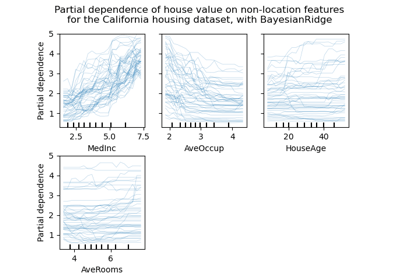

Release Highlights for scikit-learn 0.24

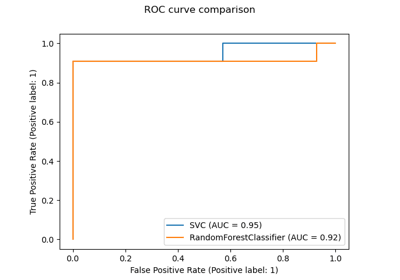

Release Highlights for scikit-learn 0.22

Classifier comparison

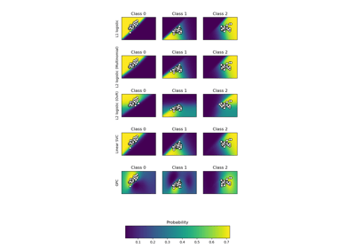

Plot classification probability

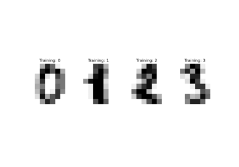

Recognizing hand-written digits

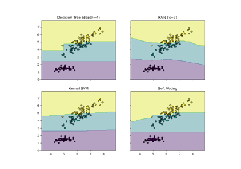

Plot the decision boundaries of a VotingClassifier

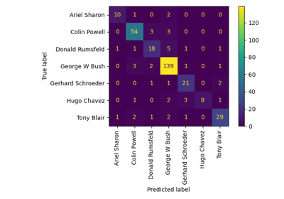

Faces recognition example using eigenfaces and SVMs

Libsvm GUI

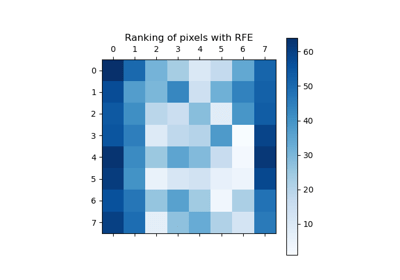

Recursive feature elimination

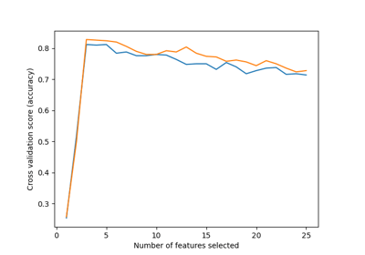

Recursive feature elimination with cross-validation

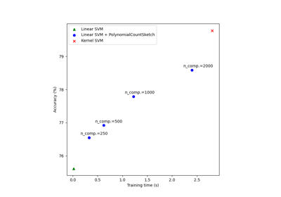

Scalable learning with polynomial kernel approximation

Displaying Pipelines

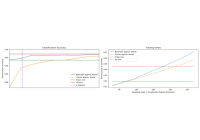

Explicit feature map approximation for RBF kernels

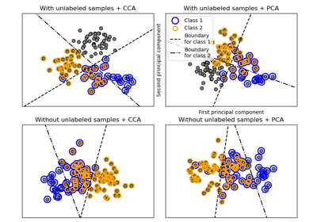

Multilabel classification

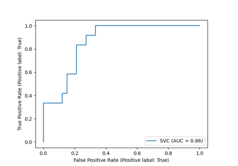

ROC Curve with Visualization API

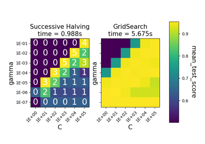

Comparison between grid search and successive halving

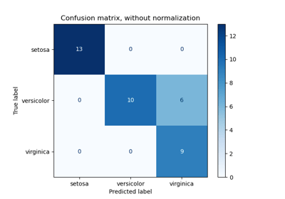

Confusion matrix

Custom refit strategy of a grid search with cross-validation

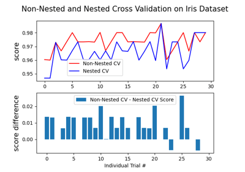

Nested versus non-nested cross-validation

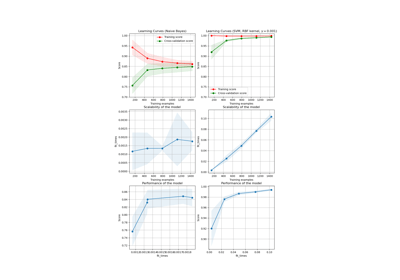

Plotting Learning Curves

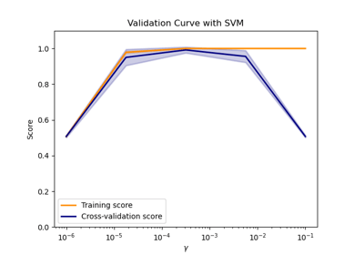

Plotting Validation Curves

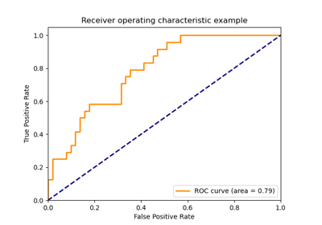

Receiver Operating Characteristic (ROC)

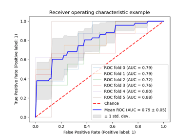

Receiver Operating Characteristic (ROC) with cross validation

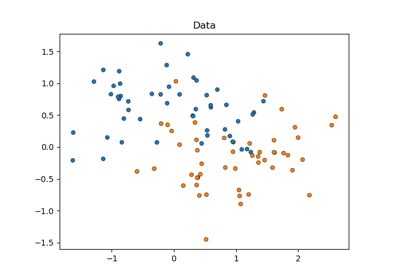

Statistical comparison of models using grid search

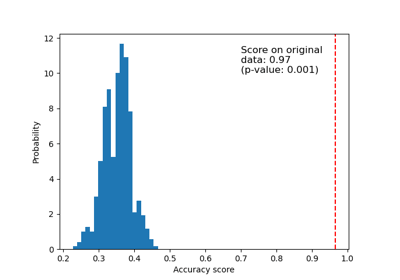

Test with permutations the significance of a classification score

Concatenating multiple feature extraction methods

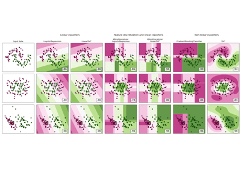

Feature discretization

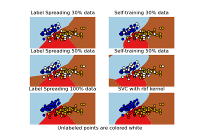

Decision boundary of semi-supervised classifiers versus SVM on the Iris dataset

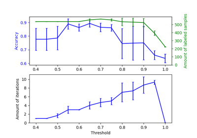

Effect of varying threshold for self-training

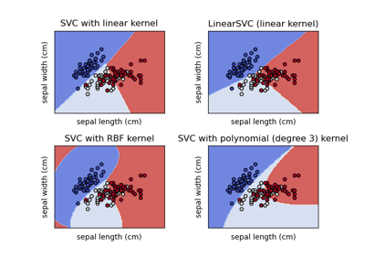

Plot different SVM classifiers in the iris dataset

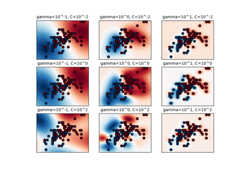

RBF SVM parameters

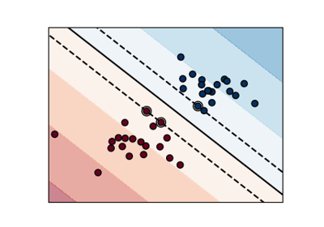

SVM Margins Example

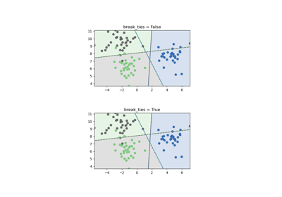

SVM Tie Breaking Example

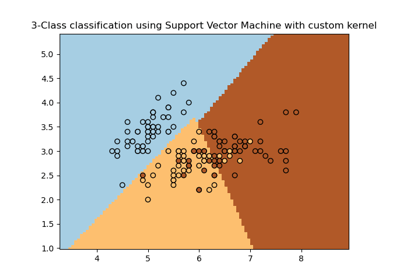

SVM with custom kernel

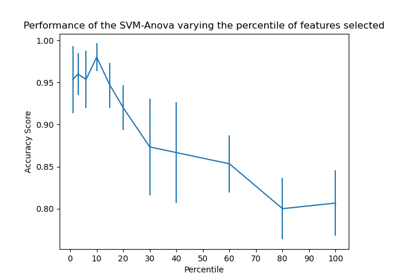

SVM-Anova: SVM with univariate feature selection

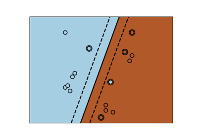

SVM-Kernels

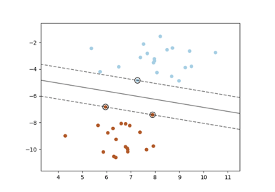

SVM: Maximum margin separating hyperplane

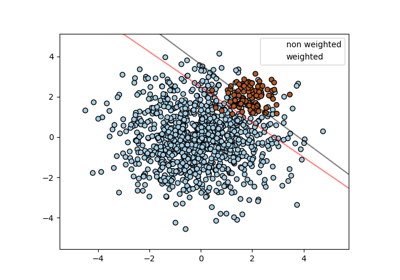

SVM: Separating hyperplane for unbalanced classes

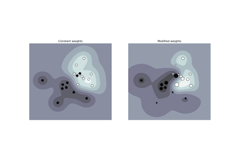

SVM: Weighted samples

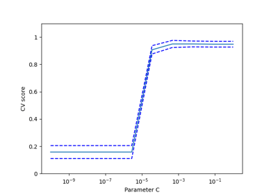

Cross-validation on Digits Dataset Exercise

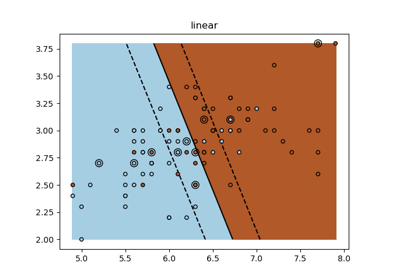

SVM Exercise

© 2007–2022 The scikit-learn developers  
Licensed under the 3-clause BSD License.  
https://scikit-learn.org/1.1/modules/generated/sklearn.svm.SVC.html